# FJUEL workshop Dynamic documents in R: Introduction to Quarto

Session 1: R project setup and Quarto documents

# Session 1: Learning goals

### Learning goals

- Understand the fundamentals of working with R
- Learn how to organize your R project and workflow
- Create and render your first quarto notebook
- Take on board some R basics

# Fundamentals

### Fundamentals

- Use R with **RStudio**
- Create an **RStudio project** for each new research project/study
- Use **notebooks** (Quarto documents), which include R code + output
- Project folder: Organization into **subfolders** (data, figures, etc.)
- Everything should always be **reproducible from code + input data**

# R projects: Setup

### Create an RStudio project

- File : New project…
- New Directory
- New Project
- Use an informative **directory name**
- Store it **where you will find it**

[figure not shown]

[figure not shown]

### RStudio project organization

- A project should be **self-contained**: All in one place
- Keep data files and .qmd-notebooks in your project folder
- Use **subfolders**: data, figures

**Reproducibility**

Your data analysis project should be self-contained, which means that everything that is needed to reproduce the results is stored in the project folder.

Learn more: Wickham & Grolemund 2023: [Chapter 8](https://r4ds.had.co.nz/workflow-projects.html) | The Turing Way [research compendia](https://the-turing-way.netlify.app/reproducible-research/compendia.html)

### RStudio project setup

- Go to your project folder
- Create two **subfolders**: data, figures

### RStudio project setup

This is what a minimal R project setup looks like:

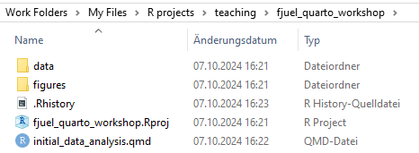

# Quarto documents

### Use notebooks (Quarto documents)

- **Quarto documents** combine text, code, and output
- Can be exported as html/Word/PDF file
- In the analysis notebook:
  - Talk to your (future) self: Say what you do (and why you do it)
  - Run analyses
  - Look at output (figures, tables,…)

[figure not shown]

The predecessor of quarto was **RMarkdown**.

### Create a Quarto document

- File : New file : Quarto document…
- Use default options, click “Create”
- Save it in your project folder
- Render it: Click the Render button

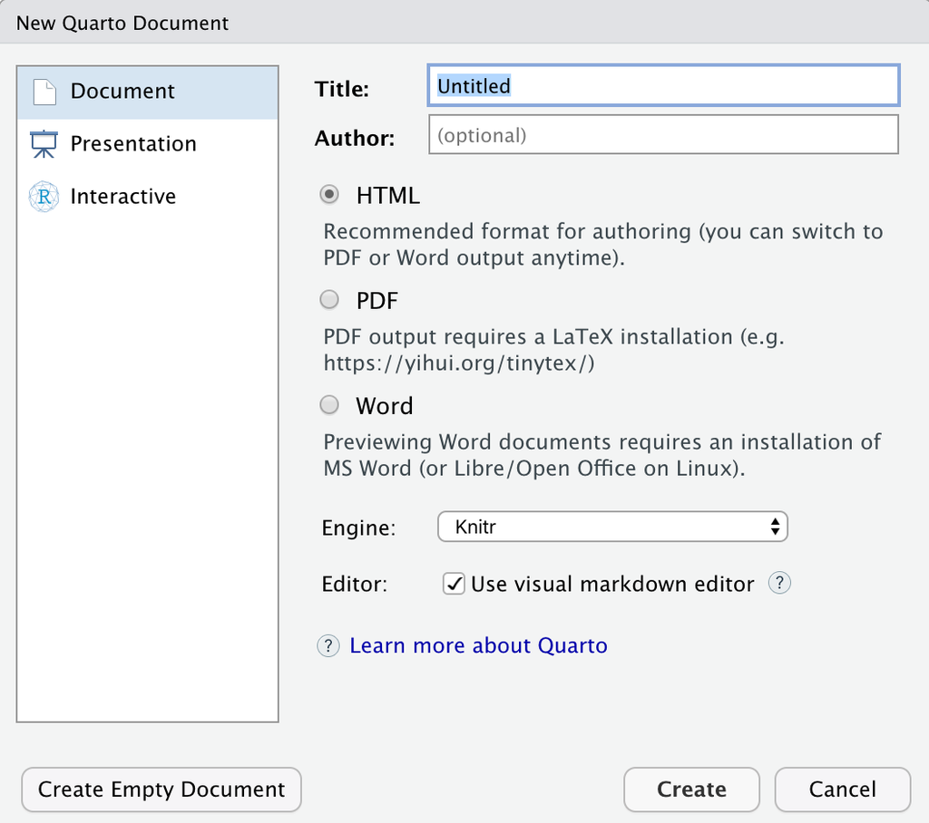

### Play around with the Quarto file

- Compare contents of file with rendered version
- Change/add text and render again
- Add headers / sub-headers
- Run code inside of RMarkdown file
- Add bold print `**bold**`
- Add italics `*italics*`
- Have a look at the [RMarkdown Cheat Sheet](https://www.rstudio.com/wp-content/uploads/2015/02/rmarkdown-cheatsheet.pdf)

# R basics

### R: General advice

- Use the **tidyverse** set of packages
- Use **ggplot2** for data visualization (Session 2)
- Workflow: Document every step using code
- Aim: Full reproducibility based on code + data

[figure not shown]

[figure not shown]

### R packages

- For some things, you need **packages** (sets of functions)
- You need to install a package only once: `install.packages()`

```r
install.packages("tidyverse")
```

- Packages must be loaded at beginning of R session: `library()`

```r
library(tidyverse)
```

- Notebooks should start with section `## R setup`, where you load the packages you need

### In R, everything is an object

- Functions, data tables, etc.
- Create an object by assigning something to a new name
- **Assignment operator**: `<-` (shortcut: Alt + -)
- New objects then exist in R’s **workspace** (top right panel)
- Important object types:
  - **Vector**: Sequence of elements (e.g. names, numbers)
  - **Data frame**/tibble: Data tables

### In R, you do things using functions

- Functions do the work in R (calculation, graphing, etc.)
- Functions have parentheses at the end of their names
- We give instructions to a function using its **arguments**
- `function(argument = "...")`

### Some useful functions

- Inspect contents of data frame: `str()`
- Inspect first few rows of data frame: `head()`
- `mean()`, `median()`
- Access columns (= variables) in a data frame: `$`

# Session 1: Practice